# 02 · Fibre type

## Load packages

```r
pacman::p_load(here, limma, dplyr, tidyr, tibble, readr, ggplot2, writexl)
here::i_am("06_Composition/02_fibre_type/a_script/02_fibre_type.qmd")
```

## Read proteins and reference

FibeRtypeR (Van der Stede et al. 2026, doi:10.1113/JP290082) reads a biopsy as a mix of pure slow and fast fibre profiles, built as in the paper from its Table S1 markers and the sex-specific fibre pools of Moesgaard et al. 2026 (doi:10.1038/s41467-026-77275-9). The limpa matrix replaces DIA-NN LFQ as input, because it measures more markers in every sample.

```r
stage <- here("06_Composition", "02_fibre_type")
proteins <- readRDS(here("01_Preprocess", "02_Quantification", "c_data", "proteins.rds"))
d <- readRDS(here("02_Differential_Expression", "01_Design", "c_data", "design.rds"))
reference <- read_csv(
  file.path(stage, "references", "fibertyper_reference.csv"), show_col_types = FALSE
)
targets <- proteins$targets
stopifnot(
  identical(rownames(d$design), targets$sample_id),
  identical(colnames(proteins$E), targets$sample_id)
)
count(reference, marker_type)
```

```
# A tibble: 2 × 2
  marker_type     n
  <chr>       <int>
1 fast           68
2 slow           77
```

## Estimate the slow fraction

For two non-negative fractions summing to one, FibeRtypeR’s least-squares fit has a closed form: the projection onto the line from the fast to the slow profile, clipped to [0, 1]. Each sample is shifted to its own sex’s reference median, because limpa’s scale differs from the deposit’s.

```r
genes <- proteins$genes$Genes
reference <- filter(reference, !is.na(slow_F + fast_F + slow_M + fast_M))
rows <- which(genes %in% reference$gene & !duplicated(genes))
bulk <- proteins$E[rows, ]
marker_profile <- reference[match(genes[rows], reference$gene), ]
slow_ref <- as.matrix(marker_profile[paste0("slow_", targets$sex)])
fast_ref <- as.matrix(marker_profile[paste0("fast_", targets$sex)])
bulk <- sweep(bulk, 2, apply(bulk, 2, median) - apply(rbind(slow_ref, fast_ref), 2, median))
direction <- slow_ref - fast_ref
slow <- colSums((bulk - fast_ref) * direction) / colSums(direction^2)
targets$slow <- pmin(pmax(slow, 0), 1)
count(marker_profile, marker_type)
```

```
# A tibble: 2 × 2
  marker_type     n
  <chr>       <int>
1 fast           48
2 slow           51
```

```r
summary(targets$slow)
```

```
   Min. 1st Qu.  Median    Mean 3rd Qu.    Max.
 0.2193  0.3498  0.4239  0.4169  0.4741  0.6969
```

## Checks without histology

No histology exists, so these ask whether the ranking behaves like fibre type: legs and repeat biopsies should agree, most variation should sit between people, and women should be slower.

```r
wide <- targets |>
  select(participant, leg, timepoint, slow) |>
  pivot_wider(names_from = c(leg, timepoint), values_from = slow)
checks <- tibble(
  check = c(
    "left vs right leg at T1 (r)", "same leg, T1 vs T2 (r)",
    "variance between participants (R2)", "women minus men (points)"
  ),
  value = c(
    cor(wide$L_T1, wide$R_T1, use = "complete.obs"),
    cor(c(wide$L_T1, wide$R_T1), c(wide$L_T2, wide$R_T2), use = "complete.obs"),
    summary(lm(slow ~ participant, targets))$r.squared,
    100 * (mean(targets$slow[targets$sex == "F"]) - mean(targets$slow[targets$sex == "M"]))
  )
)
mutate(checks, value = round(value, 2))
```

```
# A tibble: 4 × 2
  check                              value
  <chr>                              <dbl>
1 left vs right leg at T1 (r)         0.69
2 same leg, T1 vs T2 (r)              0.77
3 variance between participants (R2)  0.77
4 women minus men (points)            4.23
```

## Did training or arm shift fibre type?

The slow fraction is one row, so it gets the stage 02 design with the plain least-squares t (no moderation), as MPE does in `05_Mitochondria`.

```r
fit <- contrasts.fit(lmFit(rbind(slow = 100 * targets$slow), d$design), d$contrasts)
slow_tests <- tibble(
  contrast = colnames(d$contrasts), points = fit$coefficients[1, ],
  se = fit$stdev.unscaled[1, ] * fit$sigma, df = fit$df.residual
) |>
  mutate(
    p = 2 * pt(-abs(points / se), df),
    conf.low = points - qt(0.975, df) * se, conf.high = points + qt(0.975, df) * se
  )
group_summary <- targets |>
  summarise(mean = 100 * mean(slow), sd = 100 * sd(slow), n = n(), .by = c(treatment, timepoint))
group_summary
```

```
  treatment timepoint     mean        sd  n
1      HLRT        T1 40.72280  9.083949 33
2      HLRT        T2 41.80423 10.127833 33
3       BFR        T1 41.42951  9.682921 33
4       BFR        T2 42.83866 10.004587 32
```

```r
mutate(slow_tests, across(where(is.double), function(x) signif(x, 3)))
```

```
# A tibble: 5 × 7
  contrast                    points    se    df     p conf.low conf.high
  <chr>                        <dbl> <dbl> <int> <dbl>    <dbl>     <dbl>
1 BFR_Post-Pre                 0.961  1.32    94 0.469    -1.66      3.59
2 HLRT_Post-Pre                1.26   1.32    94 0.342    -1.36      3.88
3 BFR_Pre-HLRT_Pre             0.849  1.31    94 0.52     -1.76      3.46
4 BFR_Post-HLRT_Post           0.552  1.32    94 0.677    -2.08      3.18
5 Modality_x_Time_Interaction -0.297  1.87    94 0.874    -4.01      3.42
```

## Figure

One line per leg shows whether any leg shifted, which a group mean would hide.

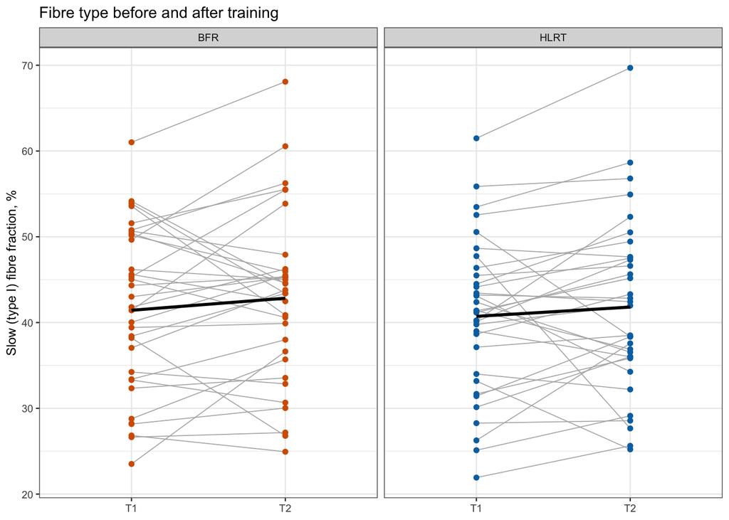

```r
figure <- targets |>
  mutate(leg_id = paste(participant, leg)) |>
  ggplot(aes(timepoint, 100 * slow, group = leg_id)) +
  geom_line(colour = "grey70", linewidth = 0.3) +
  geom_point(aes(colour = treatment), size = 1.4, show.legend = FALSE) +
  stat_summary(aes(group = 1), fun = mean, geom = "line", linewidth = 1) +
  facet_wrap(~treatment) +
  scale_colour_manual(values = c(BFR = "#D55E00", HLRT = "#0072B2")) +
  labs(
    x = NULL, y = "Slow (type I) fibre fraction, %", title = "Fibre type before and after training"
  ) +
  theme_bw(base_size = 9)
figure
```

```r
pdf(file.path(stage, "b_reports", "02_fibre_type.pdf"), width = 8.27, height = 5)
print(figure)
invisible(dev.off())
```

## Save results

```r
write_xlsx(
  list(
    slow_fraction = select(targets, sample_id, participant, leg, treatment, timepoint, sex, slow),
    contrasts = slow_tests,
    group_summary = group_summary
  ),
  file.path(stage, "c_data", "02_fibre_type.xlsx")
)
```